# Project: Investigating Medical Appointment No-shows: Exploring Factors in Predicting a No-show.

- 1. Introduction
- 2. Data Wrangling
- 3. Data Cleaning
- 4. Exploratory Data Analysis
- 5. Conclusions

## 1. Introduction

Medical appointment no-shows affect the delivery, cost of care and resource planning for medical professionals globally. In this notebook, will attempt to gather insights into the data surrounding no-shows for medical appointments and explore the question: which factors are important to take note of when trying to predict a no-show? To do this, we will be exploring approximately 110,000 medical appointments and its 14 associated variables from Brazil, put together by Joni Hoppen and Aquarela Advanced Analytics, which can be found [here](https://www.kaggle.com/joniarroba/noshowappointments). The variables provided in the dataset are as follows:

- **PatientId:** Identification of a patient
- **AppointmentID:** Identification of each appointment
- **Gender:** Male or Female
- **ScheduledDay:** The day the appointment was was made
- **AppointmentDay:** The actual appointment day
- **Age:** patient age
- **Neighbourhood:** Neighbourhood where of the appointment
- **Scholarship:** True or False; refers to a patient’s enrolment in the Brazilian Government healthcare programme; [Bolsa Família](https://en.wikipedia.org/wiki/Bolsa_Fam%C3%ADlia)
- **Hipertension:** True or False
- **Diabetes:** True or False
- **Alcoholism:** True or False
- **Handcap:** True or False
- **SMS_received:** True or False, if one or more messages has been sent to the patient
- **No-show:** True or False

With the data available, through exploring the no-show rates of values within each variable, this notebook will attempt to gain insight into the question:

### Which variables might be important to take note of when trying to predict a no-show?

With that, let’s begin by importing some libraries to help us explore the data as well as importing the data which we will be exploring.

### 1.1. Importing Libaries and loading data

```python
import pandas as pd
import numpy as np
from datetime import datetime
import matplotlib.pyplot as plt
import seaborn as sns
%matplotlib inline

df = pd.read_csv('noshowappointments-kagglev2-may-2016.csv')
```

## 2. Data Wrangling

In the following section, we will explore the data to check for errors, missing values and structure the data for further exploration. Hopefully in the process, we will be able to understand the data better and formulate more questions to be explored.

### 2.1. General Properties

```python
# First lets take a look at the first 5 line of the date to ensure it loaded in as expected
df.head()
```

|  | PatientId | AppointmentID | Gender | ScheduledDay | AppointmentDay | Age | Neighbourhood | Scholarship | Hipertension | Diabetes | Alcoholism | Handcap | SMS_received | No-show |
| --- | --- | --- | --- | --- | --- | --- | --- | --- | --- | --- | --- | --- | --- | --- |
| 0 | 2.987250e+13 | 5642903 | F | 2016-04-29T18:38:08Z | 2016-04-29T00:00:00Z | 62 | JARDIM DA PENHA | 0 | 1 | 0 | 0 | 0 | 0 | No |
| 1 | 5.589978e+14 | 5642503 | M | 2016-04-29T16:08:27Z | 2016-04-29T00:00:00Z | 56 | JARDIM DA PENHA | 0 | 0 | 0 | 0 | 0 | 0 | No |
| 2 | 4.262962e+12 | 5642549 | F | 2016-04-29T16:19:04Z | 2016-04-29T00:00:00Z | 62 | MATA DA PRAIA | 0 | 0 | 0 | 0 | 0 | 0 | No |
| 3 | 8.679512e+11 | 5642828 | F | 2016-04-29T17:29:31Z | 2016-04-29T00:00:00Z | 8 | PONTAL DE CAMBURI | 0 | 0 | 0 | 0 | 0 | 0 | No |
| 4 | 8.841186e+12 | 5642494 | F | 2016-04-29T16:07:23Z | 2016-04-29T00:00:00Z | 56 | JARDIM DA PENHA | 0 | 1 | 1 | 0 | 0 | 0 | No |

```python
# next shape of the data
df.shape
```

```
(110527, 14)
```

```python
# and some descriptive stats of our data
df.describe()
```

|  | PatientId | AppointmentID | Age | Scholarship | Hipertension | Diabetes | Alcoholism | Handcap | SMS_received |
| --- | --- | --- | --- | --- | --- | --- | --- | --- | --- |
| count | 1.105270e+05 | 1.105270e+05 | 110527.000000 | 110527.000000 | 110527.000000 | 110527.000000 | 110527.000000 | 110527.000000 | 110527.000000 |
| mean | 1.474963e+14 | 5.675305e+06 | 37.088874 | 0.098266 | 0.197246 | 0.071865 | 0.030400 | 0.022248 | 0.321026 |
| std | 2.560949e+14 | 7.129575e+04 | 23.110205 | 0.297675 | 0.397921 | 0.258265 | 0.171686 | 0.161543 | 0.466873 |
| min | 3.921784e+04 | 5.030230e+06 | -1.000000 | 0.000000 | 0.000000 | 0.000000 | 0.000000 | 0.000000 | 0.000000 |
| 25% | 4.172614e+12 | 5.640286e+06 | 18.000000 | 0.000000 | 0.000000 | 0.000000 | 0.000000 | 0.000000 | 0.000000 |
| 50% | 3.173184e+13 | 5.680573e+06 | 37.000000 | 0.000000 | 0.000000 | 0.000000 | 0.000000 | 0.000000 | 0.000000 |
| 75% | 9.439172e+13 | 5.725524e+06 | 55.000000 | 0.000000 | 0.000000 | 0.000000 | 0.000000 | 0.000000 | 1.000000 |
| max | 9.999816e+14 | 5.790484e+06 | 115.000000 | 1.000000 | 1.000000 | 1.000000 | 1.000000 | 4.000000 | 1.000000 |

In the age column, we notice that the min age is -1, which is unusual, we will investigate that later.

```python
# finally the column data type infor and counts
df.info()
```

```
<class 'pandas.core.frame.DataFrame'>
RangeIndex: 110527 entries, 0 to 110526
Data columns (total 14 columns):
 #   Column          Non-Null Count   Dtype
---  ------          --------------   -----
 0   PatientId       110527 non-null  float64
 1   AppointmentID   110527 non-null  int64
 2   Gender          110527 non-null  object
 3   ScheduledDay    110527 non-null  object
 4   AppointmentDay  110527 non-null  object
 5   Age             110527 non-null  int64
 6   Neighbourhood   110527 non-null  object
 7   Scholarship     110527 non-null  int64
 8   Hipertension    110527 non-null  int64
 9   Diabetes        110527 non-null  int64
 10  Alcoholism      110527 non-null  int64
 11  Handcap         110527 non-null  int64
 12  SMS_received    110527 non-null  int64
 13  No-show         110527 non-null  object
dtypes: float64(1), int64(8), object(5)
memory usage: 11.8+ MB
```

Also, it presents us with a little more data wrangling to be done:

- Checking for duplicated rows of data
- Looking into the unique values of certain variables for outliers and other unusual data

### 2.3. Duplicated Entries

We will look for duplicated entries by checking the **AppointmentID** variable to ensure that each row is a unique appointment

```python
df['AppointmentID'].duplicated().sum()
```

```
0
```

From the above it would seem that each entry has a unique AppointmentID, so there should not be any duplicated rows.

### 2.3. Unique Values

Next let’s go through the dataset to investigate the values present within each variable, to ensure that the data collected is sound.

```python
print("Age values include {}".format(np.sort((df['Age'].unique()))))
```

```
Age values include [ -1   0   1   2   3   4   5   6   7   8   9  10  11  12  13  14  15  16
  17  18  19  20  21  22  23  24  25  26  27  28  29  30  31  32  33  34
  35  36  37  38  39  40  41  42  43  44  45  46  47  48  49  50  51  52
  53  54  55  56  57  58  59  60  61  62  63  64  65  66  67  68  69  70
  71  72  73  74  75  76  77  78  79  80  81  82  83  84  85  86  87  88
  89  90  91  92  93  94  95  96  97  98  99 100 102 115]
```

```python
df.query("Age == -1")
```

|  | PatientId | AppointmentID | Gender | ScheduledDay | AppointmentDay | Age | Neighbourhood | Scholarship | Hipertension | Diabetes | Alcoholism | Handcap | SMS_received | No-show |
| --- | --- | --- | --- | --- | --- | --- | --- | --- | --- | --- | --- | --- | --- | --- |
| 99832 | 4.659432e+14 | 5775010 | F | 2016-06-06T08:58:13Z | 2016-06-06T00:00:00Z | -1 | ROMÃO | 0 | 0 | 0 | 0 | 0 | 0 | No |

The dataset contains an instance of where the age is recorded as -1, which cannot be true. As the -1 age only appears once through the dataset, we shall assume that it was a typo and drop the entry from the dataset during the cleaning.

```python
df['Neighbourhood'].nunique()
```

```
81
```

```python
df['Neighbourhood'].unique()
```

```
array(['JARDIM DA PENHA', 'MATA DA PRAIA', 'PONTAL DE CAMBURI',
       'REPÚBLICA', 'GOIABEIRAS', 'ANDORINHAS', 'CONQUISTA',
       'NOVA PALESTINA', 'DA PENHA', 'TABUAZEIRO', 'BENTO FERREIRA',
       'SÃO PEDRO', 'SANTA MARTHA', 'SÃO CRISTÓVÃO', 'MARUÍPE',
       'GRANDE VITÓRIA', 'SÃO BENEDITO', 'ILHA DAS CAIEIRAS',
       'SANTO ANDRÉ', 'SOLON BORGES', 'BONFIM', 'JARDIM CAMBURI',
       'MARIA ORTIZ', 'JABOUR', 'ANTÔNIO HONÓRIO', 'RESISTÊNCIA',
       'ILHA DE SANTA MARIA', 'JUCUTUQUARA', 'MONTE BELO',
       'MÁRIO CYPRESTE', 'SANTO ANTÔNIO', 'BELA VISTA', 'PRAIA DO SUÁ',
       'SANTA HELENA', 'ITARARÉ', 'INHANGUETÁ', 'UNIVERSITÁRIO',
       'SÃO JOSÉ', 'REDENÇÃO', 'SANTA CLARA', 'CENTRO', 'PARQUE MOSCOSO',
       'DO MOSCOSO', 'SANTOS DUMONT', 'CARATOÍRA', 'ARIOVALDO FAVALESSA',
       'ILHA DO FRADE', 'GURIGICA', 'JOANA D´ARC', 'CONSOLAÇÃO',
       'PRAIA DO CANTO', 'BOA VISTA', 'MORADA DE CAMBURI', 'SANTA LUÍZA',
       'SANTA LÚCIA', 'BARRO VERMELHO', 'ESTRELINHA', 'FORTE SÃO JOÃO',
       'FONTE GRANDE', 'ENSEADA DO SUÁ', 'SANTOS REIS', 'PIEDADE',
       'JESUS DE NAZARETH', 'SANTA TEREZA', 'CRUZAMENTO',
       'ILHA DO PRÍNCIPE', 'ROMÃO', 'COMDUSA', 'SANTA CECÍLIA',
       'VILA RUBIM', 'DE LOURDES', 'DO QUADRO', 'DO CABRAL', 'HORTO',
       'SEGURANÇA DO LAR', 'ILHA DO BOI', 'FRADINHOS', 'NAZARETH',
       'AEROPORTO', 'ILHAS OCEÂNICAS DE TRINDADE', 'PARQUE INDUSTRIAL'],
      dtype=object)
```

```python
print("Gender values include {}".format(df['Gender'].unique()))
print("Scholarship values include {}".format(df['Scholarship'].unique()))
print("Hypertension values include {}".format(df['Hipertension'].unique()))
print("Diabetes values include {}".format(df['Diabetes'].unique()))
print("Alcoholism values include {}".format(df['Alcoholism'].unique()))
print("Handicap values include {}".format(df['Handcap'].unique()))
print("SMS received values include {}".format(df['SMS_received'].unique()))
print("No-show values include {}".format(df['No-show'].unique()))
```

```
Gender values include ['F' 'M']
Scholarship values include [0 1]
Hypertension values include [1 0]
Diabetes values include [0 1]
Alcoholism values include [0 1]
Handicap values include [0 1 2 3 4]
SMS received values include [0 1]
No-show values include ['No' 'Yes']
```

Most of the values above returned as expected, with binary results. However, the Handicap variable returned a range of 5 values, despite being labelled as a True or False variable within the data dictionary. As such, we will be moving forward with the assumption that the values represent different categories of disabilities; with 0 being the absence of any handicap.

With that, we will proceed to the next step, data cleaning.

## 3. Data Cleaning

The things to do include:

- Drop the -1-age entry
- Fixing minor typos in the column names i.e. **Hipertension** and **Handcap** as well as renaming columns to lower case for ease
- **ScheduledDay** and **AppointmentDay** are currently stored as strings and should be converted to datetime64 format

### 3.1. Dropping invalid age entry

```python
df = df[df.Age != -1]
df.shape
```

```
(110526, 14)
```

With the one line removed, the number of rows within the dataset decreased by 1, from the original shape of (110527, 14) found at the start of our data wrangling; to (110526, 14) which we have just seen.

### 3.2. Dropping PatientId and AppointmentID columns

```python
df.drop(['PatientId', 'AppointmentID'], axis=1, inplace=True)
df.head()
```

|  | Gender | ScheduledDay | AppointmentDay | Age | Neighbourhood | Scholarship | Hipertension | Diabetes | Alcoholism | Handcap | SMS_received | No-show |
| --- | --- | --- | --- | --- | --- | --- | --- | --- | --- | --- | --- | --- |
| 0 | F | 2016-04-29T18:38:08Z | 2016-04-29T00:00:00Z | 62 | JARDIM DA PENHA | 0 | 1 | 0 | 0 | 0 | 0 | No |
| 1 | M | 2016-04-29T16:08:27Z | 2016-04-29T00:00:00Z | 56 | JARDIM DA PENHA | 0 | 0 | 0 | 0 | 0 | 0 | No |
| 2 | F | 2016-04-29T16:19:04Z | 2016-04-29T00:00:00Z | 62 | MATA DA PRAIA | 0 | 0 | 0 | 0 | 0 | 0 | No |
| 3 | F | 2016-04-29T17:29:31Z | 2016-04-29T00:00:00Z | 8 | PONTAL DE CAMBURI | 0 | 0 | 0 | 0 | 0 | 0 | No |
| 4 | F | 2016-04-29T16:07:23Z | 2016-04-29T00:00:00Z | 56 | JARDIM DA PENHA | 0 | 1 | 1 | 0 | 0 | 0 | No |

As seen from the above, we have dropped the PatientId and AppointmentId leaving us with the remaining 12 variables. Next, we will work on amending the typos in the columns names.

### 3.3. Renaming Columns

```python
df.rename(columns = {'Gender':'gender', 'ScheduledDay': 'scheduled_day', 'AppointmentDay': 'appointment_day', 'Age':'age', 'Neighbourhood':'neighbourhood','Scholarship':'scholarship','Hipertension':'hypertension','Diabetes':'diabetes', 'Alcoholism':'alcoholism', 'Handcap':'handicap','SMS_received':'sms_received','No-show':'no_show'}, inplace = True)
df.head()
```

|  | gender | scheduled_day | appointment_day | age | neighbourhood | scholarship | hypertension | diabetes | alcoholism | handicap | sms_received | no_show |
| --- | --- | --- | --- | --- | --- | --- | --- | --- | --- | --- | --- | --- |
| 0 | F | 2016-04-29T18:38:08Z | 2016-04-29T00:00:00Z | 62 | JARDIM DA PENHA | 0 | 1 | 0 | 0 | 0 | 0 | No |
| 1 | M | 2016-04-29T16:08:27Z | 2016-04-29T00:00:00Z | 56 | JARDIM DA PENHA | 0 | 0 | 0 | 0 | 0 | 0 | No |
| 2 | F | 2016-04-29T16:19:04Z | 2016-04-29T00:00:00Z | 62 | MATA DA PRAIA | 0 | 0 | 0 | 0 | 0 | 0 | No |
| 3 | F | 2016-04-29T17:29:31Z | 2016-04-29T00:00:00Z | 8 | PONTAL DE CAMBURI | 0 | 0 | 0 | 0 | 0 | 0 | No |
| 4 | F | 2016-04-29T16:07:23Z | 2016-04-29T00:00:00Z | 56 | JARDIM DA PENHA | 0 | 1 | 1 | 0 | 0 | 0 | No |

### 3.3. Change ScheduledDay and AppointmentDay data type

Next, we will strip away the time elements from both **ScheduledDay** and **AppointmentDay** and convert the data types to datetime64

```python
#stripping the time
df['appointment_day'] =df['appointment_day'].astype(str).str[:10]
df['scheduled_day'] =df['scheduled_day'].astype(str).str[:10]

# Converting the datatype to datetime64
df['scheduled_day'] = pd.to_datetime(df['scheduled_day'])
df['appointment_day'] = pd.to_datetime(df['appointment_day'])
df.dtypes
```

```
gender                     object
scheduled_day      datetime64[ns]
appointment_day    datetime64[ns]
age                         int64
neighbourhood              object
scholarship                 int64
hypertension                int64
diabetes                    int64
alcoholism                  int64
handicap                    int64
sms_received                int64
no_show                    object
dtype: object
```

As seen above, both ScheduledDay and AppointmentDay have been converted to the datetime64 format. With this, there are a few things we can do:

- Calculate the number of days between scheduling and the actual appointment, which we will store in a new column **waiting_days**
- Renaming **AppointmentDay** to **AppointmentDate**, to accurately reflect the data stored
- Then extracting the day of the week from **AppointmentDate**, into its own column **AppointmentDay**

### 3.4. Extracting waiting days

```python
# extracting number of waiting days
df['waiting_time'] = (df['appointment_day'] - df['scheduled_day']).dt.days
df.head()
```

|  | gender | scheduled_day | appointment_day | age | neighbourhood | scholarship | hypertension | diabetes | alcoholism | handicap | sms_received | no_show | waiting_time |
| --- | --- | --- | --- | --- | --- | --- | --- | --- | --- | --- | --- | --- | --- |
| 0 | F | 2016-04-29 | 2016-04-29 | 62 | JARDIM DA PENHA | 0 | 1 | 0 | 0 | 0 | 0 | No | 0 |
| 1 | M | 2016-04-29 | 2016-04-29 | 56 | JARDIM DA PENHA | 0 | 0 | 0 | 0 | 0 | 0 | No | 0 |
| 2 | F | 2016-04-29 | 2016-04-29 | 62 | MATA DA PRAIA | 0 | 0 | 0 | 0 | 0 | 0 | No | 0 |
| 3 | F | 2016-04-29 | 2016-04-29 | 8 | PONTAL DE CAMBURI | 0 | 0 | 0 | 0 | 0 | 0 | No | 0 |
| 4 | F | 2016-04-29 | 2016-04-29 | 56 | JARDIM DA PENHA | 0 | 1 | 1 | 0 | 0 | 0 | No | 0 |

```python
print('The unique values of waiting_time are: {}'.format(np.sort(df['waiting_time'].unique())))
```

```
The unique values of waiting_time are: [ -6  -1   0   1   2   3   4   5   6   7   8   9  10  11  12  13  14  15
  16  17  18  19  20  21  22  23  24  25  26  27  28  29  30  31  32  33
  34  35  36  37  38  39  40  41  42  43  44  45  46  47  48  49  50  51
  52  53  54  55  56  57  58  59  60  61  62  63  64  65  66  67  68  69
  70  71  72  73  74  75  76  77  78  79  80  81  82  83  84  85  86  87
  88  89  90  91  92  93  94  95  96  97  98 101 102 103 104 105 107 108
 109 110 111 112 115 117 119 122 123 125 126 127 132 133 139 142 146 151
 155 162 169 176 179]
```

With that, the number of days between scheduling and the actual appointment has been extracted into the new **waiting_time** column, with 0 representing same day appointments. Also, it seems that there are unusual values of -1 and -6, which may have been errors in the entry of either the **ScheduledDay** or **AppointmentDay**. As such, we will replace the values < 0 with 0 moving forward.

```python
# replaceing unusual waiting_time values
df['waiting_time'].replace([-1,-6], 0, inplace=True)
```

### 3.5. Renaming AppointmentDay to AppointmentDate and Extracting Days of the Week

```python
# Renaming AppointmentDay to AppointmentDate
df.rename(columns={'appointment_day':'appointment_date'}, inplace=True)

# Extracting Days of the Week
df['appointment_day'] = df['appointment_date'].dt.dayofweek
```

```python
df.dtypes
```

```
gender                      object
scheduled_day       datetime64[ns]
appointment_date    datetime64[ns]
age                          int64
neighbourhood               object
scholarship                  int64
hypertension                 int64
diabetes                     int64
alcoholism                   int64
handicap                     int64
sms_received                 int64
no_show                     object
waiting_time                 int64
appointment_day              int64
dtype: object
```

```python
df.head()
```

|  | gender | scheduled_day | appointment_date | age | neighbourhood | scholarship | hypertension | diabetes | alcoholism | handicap | sms_received | no_show | waiting_time | appointment_day |
| --- | --- | --- | --- | --- | --- | --- | --- | --- | --- | --- | --- | --- | --- | --- |
| 0 | F | 2016-04-29 | 2016-04-29 | 62 | JARDIM DA PENHA | 0 | 1 | 0 | 0 | 0 | 0 | No | 0 | 4 |
| 1 | M | 2016-04-29 | 2016-04-29 | 56 | JARDIM DA PENHA | 0 | 0 | 0 | 0 | 0 | 0 | No | 0 | 4 |
| 2 | F | 2016-04-29 | 2016-04-29 | 62 | MATA DA PRAIA | 0 | 0 | 0 | 0 | 0 | 0 | No | 0 | 4 |
| 3 | F | 2016-04-29 | 2016-04-29 | 8 | PONTAL DE CAMBURI | 0 | 0 | 0 | 0 | 0 | 0 | No | 0 | 4 |
| 4 | F | 2016-04-29 | 2016-04-29 | 56 | JARDIM DA PENHA | 0 | 1 | 1 | 0 | 0 | 0 | No | 0 | 4 |

From the above, we can see that the **ScheduledTime** and **AppointmentDay** have been extracted into their own columns. Do note that for **AppointmentDay** the days of the week are denoted by numbers 0 to 6 representing from Monday to Sunday respectively.

## 4. Exploratory Data Analysis (EDA)

The dataset contains plenty of information regarding the alongside, whether or not a patient showed up for their medical appointment. In this section, we will explore the relationships between each variable individually and if patients show up for their appointments, to attempt to shed insight on which factors should we take note of when trying to predict medical appointment no-shows.

### Which variables might be important to take note of when trying to predict a no-show?

Before diving into the EDA, we will create some masks below, that will help us access the no-show data within our data frame. Also, we will look into the average rate of no-shows across all the patients to get a better understanding of the dataset.

```python
no_show = df[df['no_show']=='Yes']
no_show.head()
```

|  | gender | scheduled_day | appointment_date | age | neighbourhood | scholarship | hypertension | diabetes | alcoholism | handicap | sms_received | no_show | waiting_time | appointment_day |
| --- | --- | --- | --- | --- | --- | --- | --- | --- | --- | --- | --- | --- | --- | --- |
| 6 | F | 2016-04-27 | 2016-04-29 | 23 | GOIABEIRAS | 0 | 0 | 0 | 0 | 0 | 0 | Yes | 2 | 4 |
| 7 | F | 2016-04-27 | 2016-04-29 | 39 | GOIABEIRAS | 0 | 0 | 0 | 0 | 0 | 0 | Yes | 2 | 4 |
| 11 | M | 2016-04-26 | 2016-04-29 | 29 | NOVA PALESTINA | 0 | 0 | 0 | 0 | 0 | 1 | Yes | 3 | 4 |
| 17 | F | 2016-04-28 | 2016-04-29 | 40 | CONQUISTA | 1 | 0 | 0 | 0 | 0 | 0 | Yes | 1 | 4 |
| 20 | F | 2016-04-27 | 2016-04-29 | 30 | NOVA PALESTINA | 0 | 0 | 0 | 0 | 0 | 0 | Yes | 2 | 4 |

#### Average No-show

```python
# Average percent of patients who do not show up
no_show_percentage = no_show['no_show'].count()/df['no_show'].count()
no_show_percentage
```

```
0.20193438647919945
```

It appears that on average, 20.19% of patients do not show up for their scheduled medical appointment.

### 4.1. Gender

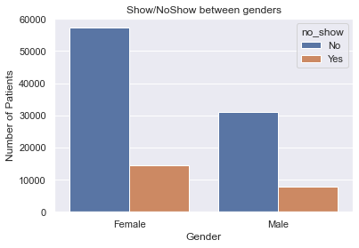

```python
# Plotting both male and female shows and no-shows
sns.set_theme(style="darkgrid")

ax = sns.countplot(x=df['gender'], hue=df['no_show'])

ax.set_title("Show/NoShow between genders")
plt.ylabel('Number of Patients')
plt.xlabel('Gender')
ax.set_xticklabels(['Female', 'Male']);
```

From the above, we can see that the ratio of no-shows between males and females appears to be even, with around 58,000 females showing up for their appointment and 14,000 who do not. For males, around 31,000 showed up for their appointment against the approximate 8,000 that did not show up.

It is also clear that the number of female’s patients have more appointments than the male patients. This may suggest that although gender may be an important factor in predicting appointments. However, as the ratio of no-shows between the genders appear to be similar, it may not be as important in predicting no-shows.

### 4.2. Age

First, let’s take a look at distribution of shows and no-shows across age.

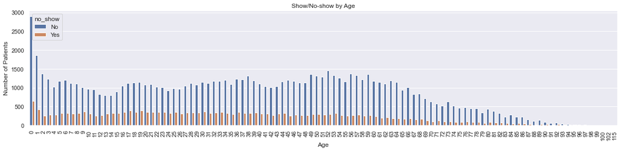

```python
# Plotting Show/No-show across Age
plt.figure(figsize=(20,4))
plt.xticks(rotation=90)

ax = sns.countplot(x=df['age'], hue=df['no_show'])

plt.ylabel('Number of Patients')
plt.xlabel('Age')
ax.set_title('Show/No-show by Age');
```

From the above, we can see that the ratio of patients who show up against those who do not seem fairly consistent across the ages and that the patients under the age of 1 also have the largest number of appointments of any age.

To get a more accurate look at the ratio of shows to no-shows, we could look into the percentage of patients who showed up for their appointments by age.

#### 4.2.1 Age by Percentage

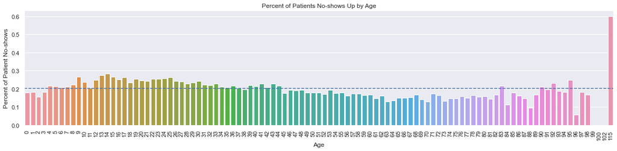

```python
# Percentage of patients that dont show up for their appointments by age
no_show_pecentage_age = no_show.groupby('age').size()/df.groupby('age').size()

# Plotting the Percentage of patients show up by age
plt.figure(figsize=(20,4))
ax = sns.barplot(x=no_show_pecentage_age.index, y=no_show_pecentage_age)

# Plotting average show up line
plt.axhline(no_show_percentage, ls='--')

plt.xticks(rotation=90)
plt.ylabel('Percent of Patient No-shows')
plt.xlabel('Age')
ax.set_title('Percent of Patients No-shows Up by Age');
```

Thus, due to the varying no-show percentages across ages, it appears that age may be a useful variable when trying to predict if a patient might not show for an appointment.

### 4.3. Neighbourhood

Next we will look into the neighbourhoods where the medical appointments were supposed to take place, specifically the number of no-shows in each neighbourhood against the average.

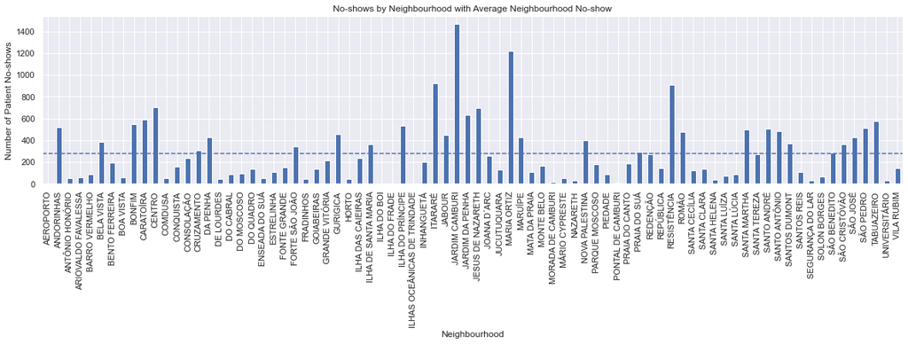

```python
# No-show Patients based on neighbourhood
neighbourhood_no_show = no_show.groupby('neighbourhood').size()

# Average neighbourhood no-show
avg_neigh_no_show = neighbourhood_no_show.sum()/df['neighbourhood'].nunique()

# Plotting No-show by neighbourhood, with average
neighbourhood_no_show.plot(kind='bar', figsize=(20,4))
plt.axhline(avg_neigh_no_show, linestyle='--')

plt.ylabel('Number of Patient No-shows')
plt.xlabel('Neighbourhood')
plt.title('No-shows by Neighbourhood with Average Neighbourhood No-show');
```

From the above, we can observe:

- The number of no-shows seems to differ significantly between neighbourhoods
- There are 31 neighbourhoods, out of 81, that have no-show counts above the average
- The top 3 neighbourhoods with the most no-show are:
  1. Jardim Camburi
  2. Maria Ortiz
  3. Itarare

For more insights into the neighbourhood data, let’s take a look into the percentages of no-shows across the various neighbourhoods.

#### 4.3. Neighbourhood by Percentage

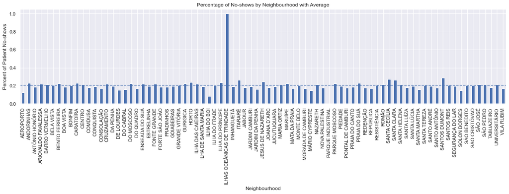

```python
# Percent of no-shows in each neighbourhood
neighbourhood_no_show_percent = no_show.groupby('neighbourhood')['age'].count()/df.groupby('neighbourhood')['age'].count()

# Average no-show percentage by neighbourhood
ave_neigh_per = neighbourhood_no_show_percent.sum()/df.neighbourhood.nunique()

#  Plotting percentage of no-shows by neighbourhood
neighbourhood_no_show_percent.plot(kind='bar', figsize=(20,4))

plt.axhline(ave_neigh_per, ls='--')

plt.ylabel('Percent of Patient No-shows')
plt.xlabel('Neighbourhood')
plt.title('Percentage of No-shows by Neighbourhood with Average');
```

```python
df.query("neighbourhood =='ILHAS OCEÂNICAS DE TRINDADE'")
```

|  | gender | scheduled_day | appointment_date | age | neighbourhood | scholarship | hypertension | diabetes | alcoholism | handicap | sms_received | no_show | waiting_time | appointment_day |
| --- | --- | --- | --- | --- | --- | --- | --- | --- | --- | --- | --- | --- | --- | --- |
| 48754 | F | 2016-04-14 | 2016-05-13 | 51 | ILHAS OCEÂNICAS DE TRINDADE | 0 | 0 | 0 | 0 | 0 | 0 | Yes | 29 | 4 |
| 48765 | F | 2016-04-14 | 2016-05-13 | 58 | ILHAS OCEÂNICAS DE TRINDADE | 0 | 0 | 0 | 0 | 0 | 0 | Yes | 29 | 4 |

```python
df.query("neighbourhood =='PARQUE INDUSTRIAL'")
```

|  | gender | scheduled_day | appointment_date | age | neighbourhood | scholarship | hypertension | diabetes | alcoholism | handicap | sms_received | no_show | waiting_time | appointment_day |
| --- | --- | --- | --- | --- | --- | --- | --- | --- | --- | --- | --- | --- | --- | --- |
| 75199 | F | 2016-05-05 | 2016-05-05 | 17 | PARQUE INDUSTRIAL | 0 | 0 | 0 | 0 | 0 | 0 | No | 0 | 3 |

From the above, we can see that the no-show across the neighbourhoods, in both values and percentage. Of course, this information may not be accurate for neighbourhoods such as **ILHAS OCEÂNICAS DE TRINDADE** and **PARQUE INDUSTRIAL** due to the lack of data, with their neighbourhoods only having 2 and 1 entries respectively. Regardless, the above may imply that the neighbourhoods where medical may be important factor to investigate when trying to predict no-shows.

However, as there are quite a few neighbourhoods whose no-show percentages which stray away from the 20% average, neighbourhoods may be a useful variable in predicting no-shows after patients make appointments.

### 4.3. Scholarship

Scholarship, as mentioned, refers to a patient’s enrolment in the Brazilian Government healthcare programme; Bolsa Família. In the following section we will investigate if the subscription to the healthcare programme may be a important factor in trying to predict no-shows.

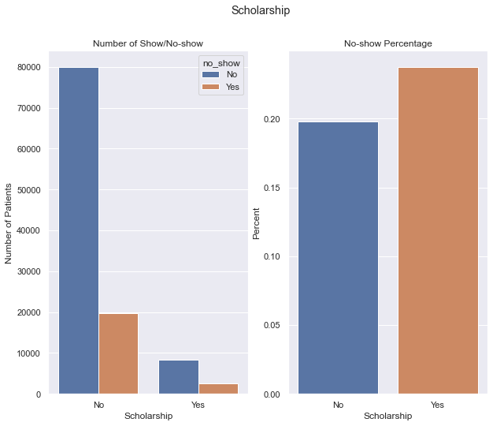

```python
#  No-show percent for no scholarship
scholar_per = no_show.groupby('scholarship')['scholarship'].count()/df.groupby('scholarship')['no_show'].count()

# sub plot for scholarship
fig, axs = plt.subplots(1, 2, figsize=(10,8))
fig.suptitle('Scholarship')

# Count plot
sns.countplot(ax=axs[0], x=df['scholarship'], hue=df['no_show'])
axs[0].set_title('Number of Show/No-show')
axs[0].set_ylabel('Number of Patients')
axs[0].set_xlabel('Scholarship')
axs[0].set_xticklabels(['No', 'Yes'])

# Percentage plot
sns.barplot(ax=axs[1], x=scholar_per.index, y=scholar_per)
axs[1].set_title('No-show Percentage')
axs[1].set_ylabel('Percent')
axs[1].set_xlabel('Scholarship')
axs[1].set_xticklabels(['No', 'Yes']);
```

### 4.4. Hypertension

Next, let's look into the numbers for patient shows and no-shows for those with and without hypertension.

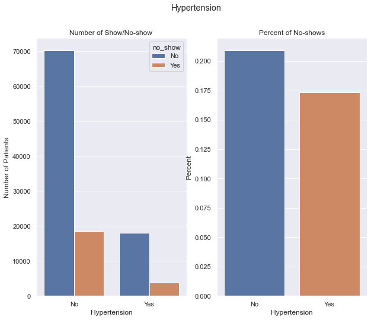

```python
#  No-show percent for Hypertension
hyper_per = no_show['hypertension'].groupby(df['hypertension']).count()/df['hypertension'].groupby(df['hypertension']).count()

# sub plot for Hypertension
fig, axs = plt.subplots(1,2, figsize=(10,8))
fig.suptitle('Hypertension')
# Count plot
sns.countplot(ax=axs[0], x=df['hypertension'], hue=df['no_show'])
axs[0].set_title('Number of Show/No-show ')
axs[0].set_xlabel('Hypertension')
axs[0].set_ylabel('Number of Patients')
axs[0].set_xticklabels(['No', 'Yes'])

# Percentage plot
sns.barplot(ax=axs[1], x=hyper_per.index, y=hyper_per)
axs[1].set_title('Percent of No-shows')
axs[1].set_xlabel('Hypertension')
axs[1].set_ylabel('Percent')
axs[1].set_xticklabels(['No', 'Yes']);
```

From the above graph on hypertension, we can observe:

- Majority of the patients do not have hypertension
- For the patients **without hypertension**
  1. Approximately 70,000 patients show up
  2. Approximately 19,000 patients that did not show
  3. Approximately 21% of patients did not show up for their appointment
- For the patients **with hypertension**
  1. Approximately 18,000 patients show up
  2. Approximately 3,000 patients that did not show
  3. Approximately 17% of patients did not show up for their appointment

Thus, due to the difference in no-show percentage between patients with and without hypertension, hypertension could be a useful in determining a no-show.

### 4.5. Diabetes

Next, we will look into the show/no-show numbers of patients regarding diabetes.

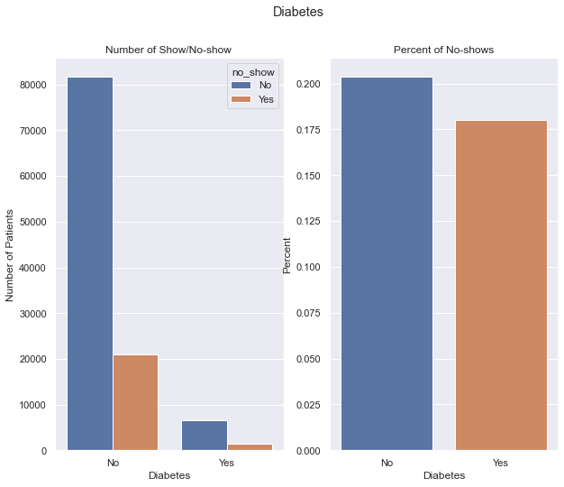

```python
#  No-show percent for no Diabetes
diabetes_per = no_show['diabetes'].groupby(df['diabetes']).count()/df.groupby(df['diabetes'])['diabetes'].count()

# sub plot for Diabetes
fig, axs = plt.subplots(1,2, figsize=(10,8))
fig.suptitle('Diabetes')

# Count plot
sns.countplot(ax=axs[0], x=df['diabetes'], hue=df['no_show'])
axs[0].set_title('Number of Show/No-show ')
axs[0].set_xlabel('Diabetes')
axs[0].set_ylabel('Number of Patients')
axs[0].set_xticklabels(['No', 'Yes'])

# Percentage plot
sns.barplot(ax=axs[1], x=diabetes_per.index, y=diabetes_per)
axs[1].set_title('Percent of No-shows')
axs[1].set_xlabel('Diabetes')
axs[1].set_ylabel('Percent')
axs[1].set_xticklabels(['No', 'Yes']);
```

From the above graph on diabetes, we can observe:

- Majority of the patients do not have diabetes
- For the patients **without diabetes**
  1. Approximately 82,000 patients show up
  2. Approximately 20,000 patients that did not show
  3. Approximately 20% of patients did not show up for their appointment
- For the patients **with diabetes**
  1. Approximately 6,000 patients show up
  2. Approximately 1,000 patients that did not show
  3. Approximately 18% of patients did not show up for their appointment

Thus, due to the difference in no-show percentage between patients with and without diabetes, although it is not as significant as some of the previous variables, might still be a useful in determining a no-show.

### 4.6. Alcoholism

Next, we will look into the show/no-show numbers of patients regarding alcoholism.

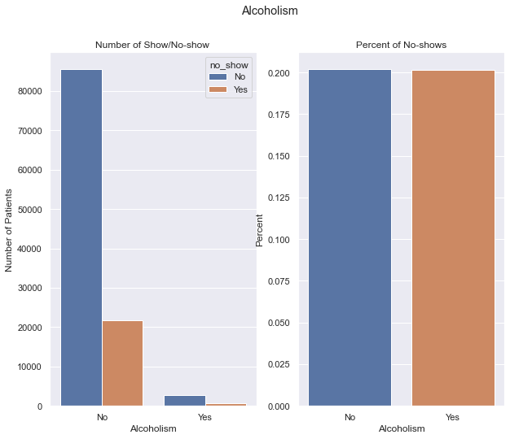

```python
#  No-show percent for no Alcoholism
alcoholism_per = no_show['alcoholism'].groupby(df['alcoholism']).count()/df.groupby(df['alcoholism'])['alcoholism'].count()

# sub plot for Alcoholism
fig, axs = plt.subplots(1,2, figsize=(10,8))
fig.suptitle('Alcoholism')

# Count plot
sns.countplot(ax=axs[0], x=df['alcoholism'], hue=df['no_show'])
axs[0].set_title('Number of Show/No-show ')
axs[0].set_xlabel('Alcoholism')
axs[0].set_ylabel('Number of Patients')
axs[0].set_xticklabels(['No', 'Yes'])

# Percentage plot
sns.barplot(ax=axs[1], x=alcoholism_per.index, y=alcoholism_per)
axs[1].set_title('Percent of No-shows')
axs[1].set_xlabel('Alcoholism')
axs[1].set_ylabel('Percent')
axs[1].set_xticklabels(['No', 'Yes']);
```

From the above graph on alcoholism, we can observe:

- Majority of the patients do not suffer from alcoholism
- For the patients who are **not alcoholics**
  1. Approximately 85,000 patients show up
  2. Approximately 20,000 patients that did not show
  3. Approximately 20% of patients did not show up for their appointment
- For the patients who are **alcoholics**
  1. Approximately 3,000 patients show up
  2. Less than 1,000 patients that did not show
  3. Approximately 20% of patients did not show up for their appointment

As the percentages of no-shows between patients identified with alcoholism and those without are both approximately 20% it seems that alcoholism will not be a useful variable in predicting no-shows.

```python
df.head()
```

|  | gender | scheduled_day | appointment_date | age | neighbourhood | scholarship | hypertension | diabetes | alcoholism | handicap | sms_received | no_show | waiting_time | appointment_day |
| --- | --- | --- | --- | --- | --- | --- | --- | --- | --- | --- | --- | --- | --- | --- |
| 0 | F | 2016-04-29 | 2016-04-29 | 62 | JARDIM DA PENHA | 0 | 1 | 0 | 0 | 0 | 0 | No | 0 | 4 |
| 1 | M | 2016-04-29 | 2016-04-29 | 56 | JARDIM DA PENHA | 0 | 0 | 0 | 0 | 0 | 0 | No | 0 | 4 |
| 2 | F | 2016-04-29 | 2016-04-29 | 62 | MATA DA PRAIA | 0 | 0 | 0 | 0 | 0 | 0 | No | 0 | 4 |
| 3 | F | 2016-04-29 | 2016-04-29 | 8 | PONTAL DE CAMBURI | 0 | 0 | 0 | 0 | 0 | 0 | No | 0 | 4 |
| 4 | F | 2016-04-29 | 2016-04-29 | 56 | JARDIM DA PENHA | 0 | 1 | 1 | 0 | 0 | 0 | No | 0 | 4 |

### 4.7. Handicap

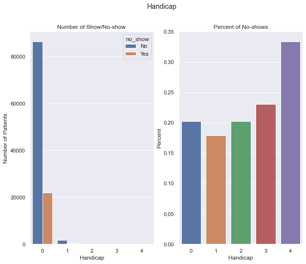

```python
#  No-show percent for no Alcoholism
handicap_per = no_show['handicap'].groupby(df['handicap']).count()/df.groupby(df['handicap'])['handicap'].count()

# sub plot for Alcoholism
fig, axs = plt.subplots(1,2, figsize=(10,8))
fig.suptitle('Handicap')

# Count plot
sns.countplot(ax=axs[0], x=df['handicap'], hue=df['no_show'])
axs[0].set_title('Number of Show/No-show ')
axs[0].set_xlabel('Handicap')
axs[0].set_ylabel('Number of Patients')

# Percentage plot
sns.barplot(ax=axs[1], x=handicap_per.index, y=handicap_per)
axs[1].set_title('Percent of No-shows')
axs[1].set_xlabel('Handicap')
axs[1].set_ylabel('Percent');
```

A for the handicap graph above, as expected, most of the patients are not handicapped.

With this, it seems that the handicap variable may be useful to consider, when determining if a patient will not show up for their appointment.

### 4.8. SMS Received

Next we will look into the variable SMS received, which represents if one or more reminder messages has been sent to the patient.

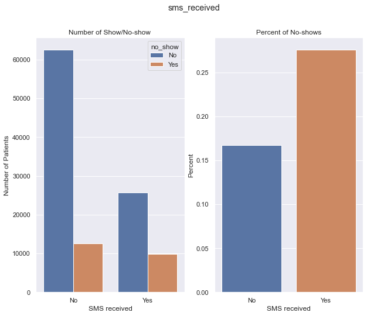

```python
#  No-show percent for no sms_received
sms_per = no_show['sms_received'].groupby(df['sms_received']).count()/df.groupby(df['sms_received'])['sms_received'].count()

# sub plot for sms_received
fig, axs = plt.subplots(1,2, figsize=(10,8))
fig.suptitle('sms_received')

# Count plot
sns.countplot(ax=axs[0], x=df['sms_received'], hue=df['no_show'])
axs[0].set_title('Number of Show/No-show ')
axs[0].set_xlabel('SMS received')
axs[0].set_ylabel('Number of Patients')
axs[0].set_xticklabels(['No', 'Yes'])

# Percentage plot
sns.barplot(ax=axs[1], x=sms_per.index, y=sms_per)
axs[1].set_title('Percent of No-shows')
axs[1].set_xlabel('SMS received')
axs[1].set_ylabel('Percent')
axs[1].set_xticklabels(['No', 'Yes']);
```

From the above graph on SMS received, we can observe:

- Majority of the patients did not receive a SMS reminder
- For the patients who **did not receive SMS**
  1. Approximately 64,000 patients show up
  2. Less than 13,000 patients that did not show
  3. Approximately 17% of patients did not show up for their appointment
- For the patients who **received SMS**
  1. Approximately 26,000 patients show up
  2. Approximately 9,500 patients that did not show
  3. Approximately 28% of patients did not show up for their appointment

Surprisingly, a higher percentage of no-show was recorded with patients who received the reminder SMS, with an estimated 11% difference between the two groups. Thus, SMS received variable might be useful in trying to predict patient no-shows

### 4.9. Waiting Time

Next, we will look into the show/no-show numbers of patients regarding the waiting time between scheduling and the actual appointment, in terms of days.

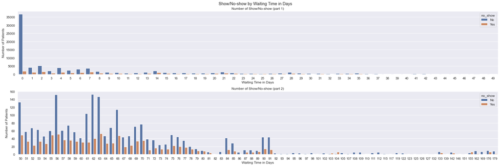

```python
# sub plot
fig, axs = plt.subplots(2, 1, figsize=(24,8))
fig.suptitle('Show/No-show by Waiting Time in Days')
fig.tight_layout(h_pad=3)

# count plot part 1
sns.countplot(ax=axs[0], x=df['waiting_time'], hue=df['no_show'], order=(sorted(df.waiting_time.unique())[:50]))
axs[0].set_title('Number of Show/No-show (part 1)')
axs[0].set_xlabel('Waiting Time in Days')
axs[0].set_ylabel('Number of Patients')

# count plot part 2
sns.countplot(ax=axs[1], x=df['waiting_time'], hue=df['no_show'], order=(sorted(df.waiting_time.unique())[50:]))
axs[1].set_title('Number of Show/No-show (part 2)')
axs[1].set_xlabel('Waiting Time in Days')
axs[1].set_ylabel('Number of Patients');
```

From the above it is clear that most of the patient’s appointments are made on the same day, represented by the ‘0’ value. Most appointments are also made within 7 days and the longest time recorded waiting time for an appointment is 179 days.

For a clearer visualisation of the no-shows by waiting days, let's look into the percentage of no show for each waiting day.

### 4.9.1. Waiting Time Percentage

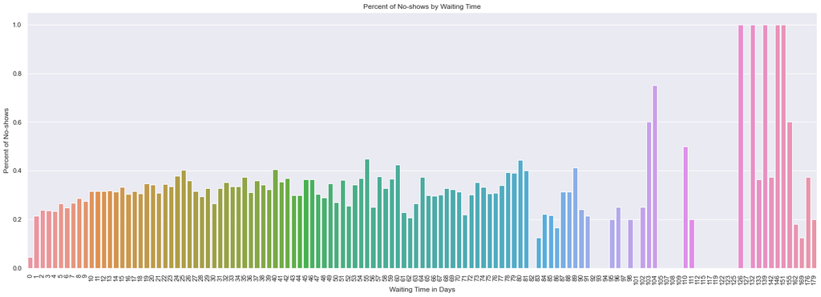

```python
# no-show percentage by waiting_time
wt_no_show_per = no_show['waiting_time'].groupby(df['waiting_time']).count()/df['waiting_time'].groupby(df['waiting_time']).count()

# Percent plot part 1

fig, ax = plt.subplots(figsize=(24,8))

sns.barplot(x=wt_no_show_per.index, y=wt_no_show_per)

ax.set_title('Percent of No-shows by Waiting Time')
ax.set_xlabel('Waiting Time in Days')
plt.xticks(rotation=90)
ax.set_ylabel('Percent of No-shows');
```

From the above, we can see that:

- As expected, the no-show percentage for same day appointments is low, at approximately 5%
- Most waiting time in days have a no-show percentage of between 20-40%
- The more larger waiting time values have more polarised percentages of either 0% or 100%, which may be due to a small number of responses

Overall, it seems that the waiting time, in term of days, would be useful variable in predicting patient no-shows.

### 4.10. Day of the Week

Next, we will look into the show/no-show numbers of patients regarding the day of the week the medical appointment is scheduled to take place.

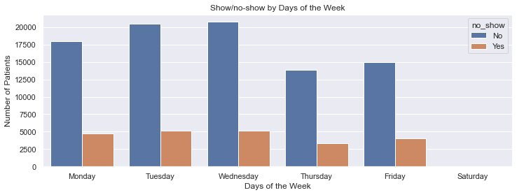

```python
fig, ax = plt.subplots(figsize=(12,4))
sns.countplot(ax=ax, x=df['appointment_day'], hue=df['no_show'])

plt.title('Show/no-show by Days of the Week')
plt.xlabel('Days of the Week')
plt.ylabel('Number of Patients')
plt.xticks([0,1,2,3,4,5],['Monday', 'Tuesday', 'Wednesday', 'Thursday', 'Friday', 'Saturday']);
```

From the above, we can observe:

- Most of the appointments take place on weekdays, between Monday to Friday, among the weekdays:
  1. Wednesday, has the most appointments, with approximately 21,000 patients showing up and 5,000 no-shows
  2. Tuesday, is 2nd, with approximately 20,000 patients showing up and 5,000 no-shows
  3. Monday, is 3rd, with approximately 18,000 patients showing up and 4,500 no-shows
  4. Friday, is 4th, with approximately 15,000 patients showing up and 3,500 no-shows
  5. Thursday, has the least appointments, with approximately 13,000 patients showing up and 3,000 no-shows
- There is a very small number of appointments that took place on Saturday.

Next let’s look into the percentage of no-shows by day of the week, for a clearer representation of the figures above.

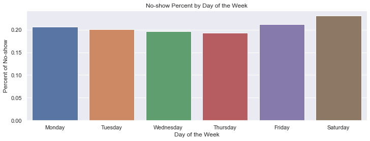

```python
# no-show percent by the day of the week
week_no_show = no_show['appointment_day'].groupby(df['appointment_day']).count()/df['appointment_day'].groupby(df['appointment_day']).count()

# size plot
fig, ax = plt.subplots(figsize=(12,4))

# count plot part 1
sns.barplot(ax=ax, x=week_no_show.index, y=week_no_show)
plt.title('No-show Percent by Day of the Week')
plt.xlabel('Day of the Week')
plt.ylabel('Percent of No-show')
plt.xticks([0,1,2,3,4,5],['Monday', 'Tuesday', 'Wednesday', 'Thursday', 'Friday', 'Saturday']);
```

From the above, we can see that the no-show percentage for the days of the week seems to all be around the 20% mark, with only Saturday showing an above average value of around 23%. This might indicate that days of the week might not be a useful indication when trying to predict no-shows.

## 5. Conclusions

#### Analysis Limitations

From analysis done in this notebook, the variables: age, neighbourhood, hypertension, handicap, diabetes, handicap, SMS received, and number of days wait may be more useful to in predicting patient no-shows. Other variables such as gender, alcoholism and the day of the medical appointment do not seem to be as important when trying to predict no-shows in the medical appointments.

As mentioned earlier, the findings in this notebook are not definitive that the mentioned variable are more important in predicting no-show. More analysis needs to be conducted to better understand the relationship between variables and how that is reflected in the no-show. The analysis done in this notebook merely a glimpse into the relationship of the variables against patient no-shows, that hopefully inspires future research into the dataset.